# NHANES Preprocessing

Glen Jan 2025

For preprocessing for all of the non-binary stuff

```r
gRootName = "nhanes"
gRootDir = "C:/Users/Glen/OneDrive - Dalhousie University/Documents"  #where scripts are
outputDir = "C:/postdoc/nhanes" #analysis directory
dataDir =  "C:/data/nhanes"
#source(sprintf("%s/logreg.R",gRootDir),verbose=0)
#source(sprintf("%s/pca.R",gRootDir),verbose=0)  #cov2
source(sprintf("%s/main.R",gRootDir),verbose=0)
source(sprintf("%s/plots.R",gRootDir),verbose=0) #TilePlot
source(sprintf("%s/survival.R",gRootDir),verbose=0) #ArrayToStartStop
#source(sprintf("%s/sf.R",gRootDir),verbose=0)
source("C:/postdoc/latent_variable_models.R")

library(tidyr) #for spread (long to wide) and gather (wide to long) #http://www.cookbook-r.com/Manipulating_data/Converting_data_between_wide_and_long_format/
library(GGally)
library(gridExtra)
library(ggrepel)
library(survival)
library(RNHANES)
```

# load in data

```r
ageCol = "RIDAGEYR"
sexCol = "RIAGENDR"
```

```r
lab = read.csv(sprintf("%s/nhanes_lab/nhanes_lab.csv",dataDir))
logi = duplicated(lab[,"SEQN"])
print(sprintf("dropping %d lab entries due to duplicates",sum(logi)))
```

```
[1] "dropping 0 lab entries due to duplicates"
```

```r
lab = lab[!logi,]
rownames(lab)=lab[,"SEQN"]
demo = read.csv(sprintf("%s/nhanes_demo/nhanes_demo.csv",dataDir))
rownames(demo)=demo[,"SEQN"]


labcodex = read.csv(sprintf("%s/nhanes_lab/nhanes_lab_vars.csv",dataDir))
rownames(labcodex)=labcodex[,"Variable.Name"]
democodex = read.csv(sprintf("%s/nhanes_demo/nhanes_demo_vars.csv",dataDir))
rownames(democodex)=democodex[,"Variable.Name"]

examcodex = read.csv(sprintf("%s/nhanes_exam/nhanes_exam_vars.csv",dataDir))
rownames(examcodex)=examcodex[,"Variable.Name"]

codex = labcodex
newvars = setdiff(rownames(democodex),rownames(codex))
codex = rbind(codex,democodex[newvars,])


#special cases:
#lookup here:
  #https://wwwn.cdc.gov/nchs/nhanes/search/default.aspx
codex["LBDCOTSI","Variable.Description"] = "Cotinine (nmol/L)"
codex[c("DCDSTAT"),"Variable.Description"] = "Lead dust status"
codex["DCDINDEX","Variable.Description"] = "Lead dust index"
codex[c("LBDD3LC"),"Variable.Description"] = "Lead dust comment"
codex[c("LBDDFSLC"),"Variable.Description"] = "Lead dust comment"
codex[c("LBDDWSLC"),"Variable.Description"] = "Lead dust comment"
codex[c("LBDZBZLC"),"Variable.Description"] = "Benzene comment"
codex[c("LBDZCFLC"),"Variable.Description"] = "Chloroform comment"
codex[c("LBDZDBLC"),"Variable.Description"] = "1,4-dichlorobenzene comment"
codex[c("LBDZEBLC"),"Variable.Description"] = "Ethylbenzene comment"
codex[c("LBDZMBLC"),"Variable.Description"] = "MTBE comment"
codex["LBDZOXLC","Variable.Description"] = "o-Xylene comment"
codex["LBDZTELC","Variable.Description"] = "Tetrachloroethene comment"
codex["LBDZTILC","Variable.Description"] = "Tetrachloroethene comment"
codex["LBDZTOLC","Variable.Description"] = "Toluene comment"
codex["LBDZXYLC","Variable.Description"] = "m,p-Xylene comment"
codex["LB2DAY","Variable.Description"] = "days between exams"
codex["LBD167LC","Variable.Description"] = "PCB167 comment code"
codex["LBDSCRSI","Variable.Description"] = "Creatinine (umol/L)"
codex["LBXPV6","Variable.Description"] = "HPV06"
codex["LBDPENLC","Variable.Description"] = "Pentadecanoic acid comment"
codex["LBX9AL","Variable.Description"] = "Nonanaldehyde (ng/mL)"
#more...
codex["LBDCOTLC","Variable.Description"] = "Cotinine detected"
#manual:
codex["LBDRFOSI","Variable.Description"] = "RBC folate (nmol/L)"
codex["SSTNT","Variable.Description"] = "Cardiac hs-Troponin T (ng/L)"
codex["SSB2M","Variable.Description"] = "Beta-2 microglobulin (mg/L)"
codex["SSCYST","Variable.Description"] = "Cystatin C (mg/L)"
codex["SSTNIALC","Variable.Description"] = "Cardiac hs-Troponin not detectable"
codex["SSTNISLC","Variable.Description"] = "Cardiac hs-Troponin comment" #0: measurable, 1: unblinded, 2: imputed
codex["SSB2M","Variable.Description"] = "Beta-2 microglobulin (mg/L)"



#check for empties and impute
logi = codex[,"Variable.Description"]==""
subcodex = codex[logi,]
for (i in 1:nrow(subcodex))
{
  v = subcodex[i,"Variable.Name"]
  logi = codex[,"Variable.Name"]==v
  d = codex[logi,"Variable.Description"]
  d = d[d!=""]
  logi[is.na(logi)] = F
  d = c(d,d,codex[logi,"Data.File.Description"][1])
  codex[logi,"Variable.Description"] = majorityVote2(d)
}
#drop duplicates
codex = codex[!duplicated(codex[,"Variable.Name"]),]
```

#exam data

```r
exam = read.csv(sprintf("%s/nhanes_exam/nhanes_exam.csv",dataDir))
rownames(exam)=exam[,"SEQN"]
```

#clean up lab data

drop lab variables related to contaminants/antigens/comments

```r
dropComments=T
if(dropComments)
{
  #descriptions
  keywords = c("comment")
  logi = grepl(keywords[1],tolower(labcodex[,"Variable.Description"]))
  logi[is.na(logi)] = F
  for (j in 2:length(keywords))
  {
    if(j < 2) break
    logiup = grepl(keywords[j],tolower(labcodex[,"Variable.Description"]))
    logiup[is.na(logiup)] = F
    logi = logi | logiup
  }
  drop = labcodex[logi,"Variable.Name"]
  print(sprintf("dropping another %d variables due to comment codes",length(drop)))
  lab = lab[,setdiff(colnames(lab),drop)]
}
```

```
[1] "dropping another 684 variables due to comment codes"
```

```r
dropWeights=T
if(dropWeights)
{
  #descriptions
  keywords = c("weight")
  logi = grepl(keywords[1],tolower(labcodex[,"Variable.Description"]))
  logi[is.na(logi)] = F
  for (j in 2:length(keywords))
  {
    if(j < 2) break
    logiup = grepl(keywords[j],tolower(labcodex[,"Variable.Description"]))
    logiup[is.na(logiup)] = F
    logi = logi | logiup
  }
  drop = labcodex[logi,"Variable.Name"]
  print(sprintf("dropping another %d variables due to weights",length(drop)))
  lab = lab[,setdiff(colnames(lab),drop)]
}
```

```
[1] "dropping another 354 variables due to weights"
```

```r
dropContaminants=T
if(dropContaminants)
{
  #files
  keywords = c("cadmium","phthalates","dioxins","volatile organic","pesticides","allergens","perfluoroalkyl")
  logi = grepl(keywords[1],tolower(labcodex[,"Data.File.Description"]))
  logi[is.na(logi)] = F
  for (j in 2:length(keywords))
  {
    if(j < 2) break
    logiup = grepl(keywords[j],tolower(labcodex[,"Data.File.Description"]))
    logiup[is.na(logiup)] = F
    logi = logi | logiup
  }
  drop = labcodex[logi,"Variable.Name"]
  print(sprintf("dropping %d variables due to contaminants",length(drop)))
  lab = lab[,setdiff(colnames(lab),drop)]

  #descriptions
  keywords = c("pcb","dioxin")
  logi = grepl(keywords[1],tolower(labcodex[,"Variable.Description"]))
  logi[is.na(logi)] = F
  for (j in 2:length(keywords))
  {
    if(j < 2) break
    logiup = grepl(keywords[j],tolower(labcodex[,"Variable.Description"]))
    logiup[is.na(logiup)] = F
    logi = logi | logiup
  }
  drop = labcodex[logi,"Variable.Name"]
  print(sprintf("dropping another %d variables due to contaminants",length(drop)))
  lab = lab[,setdiff(colnames(lab),drop)]
}
```

```
[1] "dropping 1069 variables due to contaminants"
[1] "dropping another 300 variables due to contaminants"
```

```r
dropAntigensDisease=T
if(dropAntigensDisease)
{

  #files
  keywords = c("antigen","hepatitis","toxoplasma")
  logi = grepl(keywords[1],tolower(labcodex[,"Data.File.Description"]))
  logi[is.na(logi)] = F
  for (j in 2:length(keywords))
  {
    if(j < 2) break
    logiup = grepl(keywords[j],tolower(labcodex[,"Data.File.Description"]))
    logiup[is.na(logiup)] = F
    logi = logi | logiup
  }
  drop = labcodex[logi,"Variable.Name"]
  print(sprintf("dropping %d variables due to antigens or disease",length(drop)))
  lab = lab[,setdiff(colnames(lab),drop)]
}
```

```
[1] "dropping 89 variables due to antigens or disease"
```

drop non-numeric lab

```r
dropNonNumeric=T
if(dropNonNumeric)
{
  drop=numeric()
  for (j in 1:ncol(lab))
  {
    if(!is.numeric(lab[,j])) drop = c(drop,j)
  }
  print(sprintf("dropping another %d variables that aren't numeric",length(drop)))
  lab = lab[,-drop]
}
```

```
[1] "dropping another 34 variables that aren't numeric"
```

drop rare measurements

```r
minN = 50
logi = apply(!is.na(lab),2,sum) >= minN
print(sprintf("dropping %d variables with insufficient data (min %d)",sum(!logi),minN))
```

```
[1] "dropping 6 variables with insufficient data (min 50)"
```

```r
lab = lab[,logi]
```

add new composite lab variables

```r
#add chronic inflammation
#LB2CRP is subset of LBXCRP
infVars = c(crp="LBXCRP",fib="LBXFB",neut="LBDNENO",lymph="LBDLYMNO",mono="LBDMONO",plate="LBXPLTSI")
#apply(lab[,infVars],2,range,na.rm=T)
#they're all positive except 2 values for monocytes

#FIB_TO_CRP different from others (correlations)
lab[,"FIB_TO_CRP"] = lab[,"LBXFB"]/lab[,"LB2CRP"]
#neutrophil-to-lymphocyte ratio
lab[,"NLR"] = lab[,"LBDNENO"]/lab[,"LBDLYMNO"]
#lymphocyte-to-monocyte ratio
mono = lab[,"LBDMONO"]
logi = mono < .1
logi[is.na(logi)] = F
mono[logi]  = .1 #bottom code for log transform #sort(temp[,"LBDMONO"])[1:10] #0.0 0.0 0.1 0.1
lab[,"LMR"] = lab[,"LBDLYMNO"]/mono
#platelet-to-lymphocyte ratio
lab[,"PLR"] = lab[,"LBXPLTSI"]/lab[,"LBDLYMNO"]

#pooled counts seems like immune mediated chronic inflammation
lab[,"IMMUNEINF"] = scale(log(lab[,"NLR"]))-scale(log(lab[,"LMR"]))+scale(log(lab[,"PLR"]))
lab[,"IMMUNEINF"] = lab[,"IMMUNEINF"]/3
logi = lab[,"IMMUNEINF"] < -5 #top-code outliers
logi[is.na(logi)] = F
lab[logi,"IMMUNEINF"] = -5
logi = lab[,"IMMUNEINF"] > 5 #top-code outliers
logi[is.na(logi)] = F
lab[logi,"IMMUNEINF"] = 5
lab[,"IMMUNEINF"] = exp(lab[,"IMMUNEINF"]) #rescale, will de-scale later

labcodex["IMMUNEINF","Variable.Name"] = "IMMUNEINF"
labcodex["IMMUNEINF","Data.File.Description"] = "Chronic inflammation"
labcodex["IMMUNEINF","Variable.Description"] = "imm. c. inflammation"

labcodex["FIB_TO_CRP","Variable.Name"] = "FIB_TO_CRP"
labcodex["FIB_TO_CRP","Data.File.Description"] = "Chronic inflammation"
labcodex["FIB_TO_CRP","Variable.Description"] = "fibrinogen to crp"

labcodex["NLR","Variable.Name"] = "NLR"
labcodex["NLR","Data.File.Description"] = "Chronic inflammation"
labcodex["NLR","Variable.Description"] = "imm. c. inflammation"

labcodex["LMR","Variable.Name"] = "LMR"
labcodex["LMR","Data.File.Description"] = "Chronic inflammation"
labcodex["LMR","Variable.Description"] = "imm. c. inflammation"

labcodex["PLR","Variable.Name"] = "PLR"
labcodex["PLR","Data.File.Description"] = "Chronic inflammation"
labcodex["PLR","Variable.Description"] = "imm. c. inflammation"
```

more complex inflammation

```r
#temp = lab[,infVars]
#logi = temp[,"LBDMONO"] < .1
#logi[is.na(logi)] = F
#temp[logi,"LBDMONO"]  = .1 #bottom code for log transform #sort(temp[,"LBDMONO"])[1:10] #0.0 0.0 0.1 0.1
#for (j in 1:ncol(temp)) temp[,j] = scale(log(temp[,j]))

#pc = prcomp2(temp)
#plot(pc$sdev) #I see three
#chat gpt says: all same direction is overall inflammation, CRP high and lymphocyte low is acute (high) vs chronic (low), PC3 (neno+mono vs fib+platelet) is coagulation vs immune inflammation
```

combine repeated lab variables issues: -lots of repeated measurements with different units -some use different methods so they’re correlated but different -better to drop based on correlations, I think

```r
remove_parentheticals <- function(text) {
  gsub("\\([^)]*\\)", "", text)
}

remove_punctuation <- function(text) {
  gsub("[[:punct:]]", "", text)
}

remove_whitespace <- function(text) {
  gsub("\\s+", "", text)
}
```

```r
#nm = codex[colnames(lab),"Variable.Description"]
#for (i in 1:length(nm))
#{
#  nm[i] = remove_parentheticals(nm[i])
#  nm[i] = remove_punctuation(nm[i])
#  nm[i] = remove_whitespace(nm[i])
#  nm[i] = tolower(nm[i])
#}
#logi = nm%in%nm[which(duplicated(nm))]
#View(codex[colnames(lab)[logi],])
```

specific combinations i.e. variables that were measured in different waves with different names but are otherwise the same

```r
CombineVars = function(x,v1,v2)
{
  logi = is.na(x[,v1])
  x[logi,v1] = x[logi,v2]
  x[,v2] = x[,v1]
  return(x)
}
#free t3
#vars=c("SST3F", "LBXT3F")
#logi = is.na(lab[,"LBXT3F"])
#lab[logi,"LBXT3F"] = lab[logi,"SST3F"]
#lab[,"SST3F"] = lab[,"LBXT3F"]

lab = CombineVars(lab,"LBXT3F","SST3F") #free t3
lab = CombineVars(lab,"LBXCPSI","LB2CPSI") #c-peptide #not necessary but whatever
lab = CombineVars(lab,"SSCYST","SSCYPC") #cystatin
#SSSHBG and LBXSHBG are the same but have difference medians/distributions even when age/sex corrected so I don't want to pool them
```

automated combiner

```r
corCut = .97
minN = 100
impute=T
drop=rep(F,ncol(lab))
print("correlation-based exclusions:")
for (i in 1:(ncol(lab)-1))
{
  if(drop[i]) next
  for (j in (i+1):ncol(lab))
  {
    logiI = !is.na(lab[,i])
    logiJ = !is.na(lab[,j])
    logi = logiI & logiJ
    if(sum(logi) < minN) next #not enough data
    rho = cor(lab[logi,i],lab[logi,j],use='pairwise.complete')
    if(is.na(rho)) next
    if(rho > corCut)
    {
      #one must be a subset of the other
      if(all(logiI[logiJ])) #all J are in I, so keep I
      {
        drop[j]=T
        print(sprintf("%s (%s) and %s (%s) correlated past cut of %.02f (rho: %.2f; keeping i)",codex[colnames(lab)[i],"Variable.Description"],colnames(lab)[i],codex[colnames(lab)[j],"Variable.Description"],colnames(lab)[j],corCut,rho))
      }
      else if(all(logiJ[logiI])) #all I are in J, so keep J
      {
        drop[i]=T
        print(sprintf("%s (%s) and %s (%s) correlated past cut of %.02f (rho: %.2f; keeping j)",codex[colnames(lab)[i],"Variable.Description"],colnames(lab)[i],codex[colnames(lab)[j],"Variable.Description"],colnames(lab)[j],corCut,rho))
      }
      else
      {
        if(impute)
        {
          mod = lm(i~j,data.frame(i=lab[logi,i],j=lab[logi,j]))
          lab[logiJ & !logiI,i] = predict(mod,data.frame(j=lab[logiJ & !logiI,j]))
          print(sprintf("%s (%s) and %s (%s) correlated past cut of %.02f (rho: %.2f; IMPUTING and keeping i)",codex[colnames(lab)[i],"Variable.Description"],colnames(lab)[i],codex[colnames(lab)[j],"Variable.Description"],colnames(lab)[j],corCut,rho))
          drop[j]=T
        }
        else
        {
          print(sprintf("NON-OVERLAPPING %s (%s) and %s (%s) correlated but skipping",codex[colnames(lab)[i],"Variable.Description"],colnames(lab)[i],codex[colnames(lab)[j],"Variable.Description"],colnames(lab)[j],corCut,rho))
        }
      }

    }
  }
  if(drop[i]) next
}
print(sprintf("dropping %d variables that are collinear (cor > %.02f)",sum(drop),corCut))
lab = lab[,!drop]
```

[output not shown]

pre-screen to find significant correlations with age…

```r
pt = intersect(rownames(demo),rownames(lab))
lab[,"age"] = NA
lab[pt,"age"] = demo[pt,"RIDAGEYR"]

C1 = cor(lab[,"age"],lab,use='pairwise.complete',method='spearman')[1,]

p1 = numeric()
for (i in 1:ncol(lab)) p1[i] = tryCatch(cor.test(lab[,"age"],lab[,i],use='pairwise.complete',method='spearman')$p.value,error=function(e)return(Inf))
p1[is.na(p1)] = 1
```

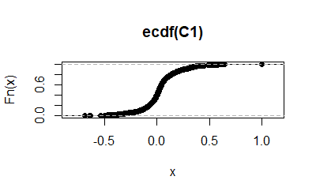

```r
plot(ecdf(C1))
```

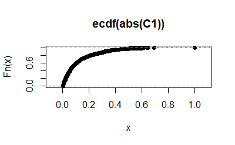

```r
plot(ecdf(abs(C1)))
```

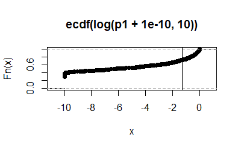

```r
plot(ecdf(log(p1+1e-10,10)))
abline(v=log(.05,10))
```

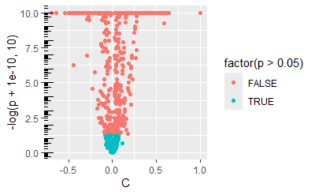

```r
df = data.frame(p=p1,C=C1)
ggplot(df,aes(x=C,y=-log(p+1e-10,10),colour=factor(p>0.05)))+
  geom_point()+
  #scale_y_log10()+
  annotation_logticks(sides="l")
```

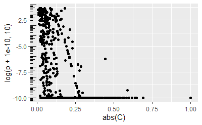

```r
ggplot(subset(df,p<.05),aes(x=abs(C),y=log(p+1e-10,10)))+
  geom_point()+
  #scale_y_log10()+
  annotation_logticks(sides="l")
```

#cut all weak and/or non-significant correlations

```r
#logi = abs(C1)>.1 & p1 < .05
logi = p1 < .05
logi[is.na(logi)] = F
labVars = colnames(lab)[logi]
#View(labcodex[useLabVars,])

#specific drops - because these aren't in older peopel!
#Chlamydia, Cytomegalovirus, Epstein Barr, Epstein Barr Index, Herpes I, Varicella
labVars = setdiff(labVars,c("URXUCL", "LBXIGG", "SSEBV", "SSEBVIND", "SSXHE1", "VARICELL"))

#drop weird binary/multinomial variables - mostly comments
u = apply(lab[,labVars],2,unlen)
labVars = labVars[u >= 10]
```

#check for non-normal behaviour

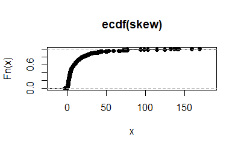

```r
skew = apply(lab[,labVars],2,skew,na.rm=T) #excess skew
plot(ecdf(skew))
```

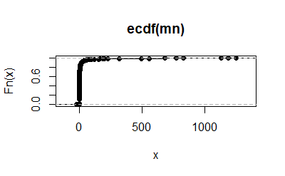

```r
mn = apply(lab[,labVars],2,min,na.rm=T)
plot(ecdf(mn))
```

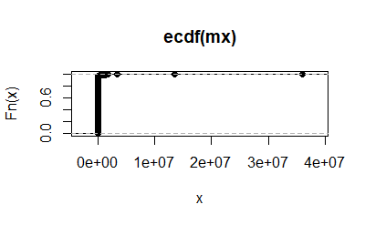

```r
mx = apply(lab[,labVars],2,max,na.rm=T)
plot(ecdf(mx))
```

add age and sex for cuts

```r
lab[,"sex"] = NA
pts = intersect(rownames(lab),rownames(demo))
lab[pts,"sex"] = demo[pts,"RIAGENDR"]-1
lab[,"age"] = NA
lab[pts,"age"] = demo[pts,"RIDAGEYR"]
```

```r
#fix negatives - not possible to have negative values, so assume they're a mistake
#estradiol
logi = lab[,"SSSE2"] < 0
logi[is.na(logi)] = F
lab[logi,"SSSE2"] = NA
#testosterone
logi = lab[,"SSTESTO"] < 0
logi[is.na(logi)] = F
lab[logi,"SSTESTO"] = NA
```

transform note: some aren’t available for all ages (so pick big range) or all sexes (logicals should handle this)

```r
labpp = lab[,labVars]

# Inverse Hyperbolic Sine (IHS) / Arsinh Transformation
IHS = function(x) return(log(x+sqrt(x^2+1))) #handles 0s #this is inverse of sinh
IHSInv = function(x) return(sinh(x))
LogEps = function(x,epsilon=0) return(log(x+epsilon)) #can't deal with 0s
LogEpsInv = function(x,epsilon=0) return(exp(x)-epsilon)

PickLogEpsOld = function(x,epsilon0=.1,lower=1e-10,upper=quantile(x,probs=.9,na.rm=T))
{
  Obj = function(par)
  {
    e = skew(LogEps(x,exp(par)))^2
    e[e <= -Inf] = 1e20
    e[is.nan(e)] = 1e20
    return(sum(e,na.rm=T))
  }
  op = optim(log(epsilon0),Obj,method="Brent",lower=log(lower),upper=log(upper))
  return(exp(op$par))
}
PickLogEps = function(x,males,females,epsilon0=.1,lower=1e-10,upper=quantile(x,probs=.9,na.rm=T))
{
  Obj = function(par)
  {
    y = LogEps(x,exp(par))
    y[males] = (y[males]-mean(y[males],na.rm=T))/sd(y[males],na.rm=T)
    y[females] = (y[females]-mean(y[females],na.rm=T))/sd(y[females],na.rm=T)
    e = skew(y)^2
    e[e <= -Inf] = 1e20
    e[is.nan(e)] = 1e20
    return(sum(e,na.rm=T))
  }
  op = optim(log(epsilon0),Obj,method="Brent",lower=log(lower),upper=log(upper))
  return(exp(op$par))
}
#I don't like this range because of menopause
#ageLogi = lab[,"age"] <= 60 & lab[,"age"] >= 40 #some variables aren't measured in all age ranges, this is the smallest range that gets them all
#ageLogi[is.na(ageLogi)] = F
ageLogi = lab[,"age"] >= 20 #avoids issues with menopause by just using everybody
ageLogi[is.na(ageLogi)] = F
olderLogi = lab[,"age"] > 60  #will use later
olderLogi[is.na(olderLogi)] = F

Mlogi = lab[,"sex"] == 0
Mlogi[is.na(Mlogi)] = F
Flogi = lab[,"sex"] == 1
Flogi[is.na(Flogi)] = F
standardize=T
binary = rep(F,length(labVars))
mpar = data.frame(var=labVars,sex="M",trans="identity",transPar=0,Nfit=NA,mu=NA,sd=NA)
fpar = data.frame(var=labVars,sex="F",trans="identity",transPar=0,Nfit=NA,mu=NA,sd=NA)
drop = binary
for (j in 1:length(labVars))  #shouldn't do anything anymore (I exclude earlier)
{
  cat(".")
  l = unlen(lab[,labVars[j]])
  if(l < 2)
  {
    drop[j] = T
    next
  }
  else if (l == 2) #shouldn't do anything anymore (I exclude earlier)
  {
    binary[j] = T
    next
  }
  else
  {
    #compare transformed to untransformed and take best one
    y = lab[,labVars[j]]
    mm = mean(y[ageLogi & Mlogi],na.rm=T)
    sm = sd(y[ageLogi & Mlogi],na.rm=T)
    Nm = sum(!is.na(y[ageLogi & Mlogi]))

    mf = mean(y[ageLogi & Flogi],na.rm=T)
    sf = sd(y[ageLogi & Flogi],na.rm=T)
    Nf = sum(!is.na(y[ageLogi & Flogi]))


      #pick lowest composite skew
      if(Nm >= 2 & Nf >= 2) #use both
      {

          #compute skew...
      skm = skew((y[ageLogi & Mlogi]-mm)/sm)
      ymt1 = IHS(y[ageLogi & Mlogi])
      mm1 = mean(ymt1,na.rm=T)
      sm1 = sd(ymt1,na.rm=T)
      skm1 = skew((ymt1-mm1)/sm1)

      skf = skew((y[ageLogi & Flogi]-mf)/sf)
      yft1 = IHS(y[ageLogi & Flogi])
      mf1 = mean(yft1,na.rm=T)
      sf1 = sd(yft1,na.rm=T)
      skf1 = skew((yft1-mf1)/sf1)

      #pick one epsilon for both sexes, otherwise it gets goofy
      e = PickLogEps(y[ageLogi],males=Mlogi[ageLogi],females=Flogi[ageLogi])
      em = e
      ef = e
      ymt2 = LogEps(y[ageLogi & Mlogi],em)
      mm2 = mean(ymt2,na.rm=T)
      sm2 = sd(ymt2,na.rm=T)
      skm2 = skew((ymt2-mm2)/sm2)
      #ef = PickLogEps(y[ageLogi & Flogi])
      yft2 = LogEps(y[ageLogi & Flogi],ef)
      mf2 = mean(yft2,na.rm=T)
      sf2 = sd(yft2,na.rm=T)
      skf2 = skew((yft2-mf2)/sf2)

          dsk1 = abs(skm1)+abs(skf1)-abs(skm)-abs(skf) #smaller = better, > 0 means no transformation is best
          dsk2 = abs(skm2)+abs(skf2)-abs(skm)-abs(skf)
      }
      else if(Nm >= 2) #use just males
      {
            #compute skew...
      skm = skew((y[ageLogi & Mlogi]-mm)/sm)
      ymt1 = IHS(y[ageLogi & Mlogi])
      mm1 = mean(ymt1,na.rm=T)
      sm1 = sd(ymt1,na.rm=T)
      skm1 = skew((ymt1-mm1)/sm1)
      em = PickLogEps(y[ageLogi & Mlogi],males=Mlogi[ageLogi & Mlogi],females=Flogi[ageLogi & Mlogi])
      ef = em
      ymt2 = LogEps(y[ageLogi & Mlogi],em)
      mm2 = mean(ymt2,na.rm=T)
      sm2 = sd(ymt2,na.rm=T)
      skm2 = skew((ymt2-mm2)/sm2)


          dsk1 = abs(skm1)+abs(skm) #smaller = better, > 0 means no transformation is best
          dsk2 = abs(skm2)+abs(skm)
      }
      else if (Nf >= 2) #use just females
      {
            #compute skew...
      skf = skew((y[ageLogi & Flogi]-mf)/sf)
      yft1 = IHS(y[ageLogi & Flogi])
      mf1 = mean(yft1,na.rm=T)
      sf1 = sd(yft1,na.rm=T)
      skf1 = skew((yft1-mf1)/sf1)
      ef = PickLogEps(y[ageLogi & Flogi],males=Mlogi[ageLogi & Flogi],females=Flogi[ageLogi & Flogi])
      em = ef
      yft2 = LogEps(y[ageLogi & Flogi],ef)
      mf2 = mean(yft2,na.rm=T)
      sf2 = sd(yft2,na.rm=T)
      skf2 = skew((yft2-mf2)/sf2)


          dsk1 = abs(skf1)-abs(skf) #smaller = better, > 0 means no transformation is best
          dsk2 = abs(skf2)-abs(skf)
      }
      else #no trans best
      {
        dsk1 = 1
        dsk2 = 1
      }

      if(dsk1 < 0 & dsk1 < dsk2) #transformation 1 best
      {
        #print("t1")
        mpar[j,"trans"] = "IHS"
        fpar[j,"trans"] = "IHS"
        mpar[j,"Nfit"] = Nm
        mpar[j,"mu"] = mm1
        mpar[j,"sd"] = sm1
        fpar[j,"Nfit"] = Nf
        fpar[j,"mu"] = mf1
        fpar[j,"sd"] = sf1

        labpp[Mlogi,labVars[j]] = (IHS(lab[Mlogi,labVars[j]])-mm1)/sm1
        labpp[Flogi,labVars[j]] = (IHS(lab[Flogi,labVars[j]])-mf1)/sf1

      } else if(dsk2 < 0 & dsk2 < dsk1) #transformation 2 best
      {
        #print("t2")
        mpar[j,"trans"] = "LogEps"
        fpar[j,"trans"] = "LogEps"
        mpar[j,"transPar"] = em
        fpar[j,"transPar"] = ef
        mpar[j,"Nfit"] = Nm
        mpar[j,"mu"] = mm2
        mpar[j,"sd"] = sm2
        fpar[j,"Nfit"] = Nf
        fpar[j,"mu"] = mf2
        fpar[j,"sd"] = sf2

        labpp[Mlogi,labVars[j]] = (LogEps(lab[Mlogi,labVars[j]],em)-mm2)/sm2
        labpp[Flogi,labVars[j]] = (LogEps(lab[Flogi,labVars[j]],ef)-mf2)/sf2

      } else #no transformation best
      {
        #print("no t")
        mpar[j,"Nfit"] = Nm
        mpar[j,"mu"] = mm
        mpar[j,"sd"] = sm
        fpar[j,"Nfit"] = Nf
        fpar[j,"mu"] = mf
        fpar[j,"sd"] = sf

        labpp[Mlogi,labVars[j]] = (lab[Mlogi,labVars[j]]-mm)/sm
        labpp[Flogi,labVars[j]] = (lab[Flogi,labVars[j]]-mf)/sf
      }


  }
}
```

```
............................................................................................................................................................................................................................................................................................................…
```

```r
save=T
if(save)
{
  write.csv(mpar,sprintf("%s/data/nhanes_male_lab_mean_sd.csv",outputDir))
  write.csv(fpar,sprintf("%s/data/nhanes_female_lab_mean_sd.csv",outputDir))
}
```

```
Error in file(file, ifelse(append, "a", "w")) :
  cannot open the connection
```

check cleaned up data -mean and skew should be near 0, sd should be near 1 AT AGE 40-60 #depends on age range used, I may use ages 20+ (you have to look in prev block) -strongly age-dependent can be quite different

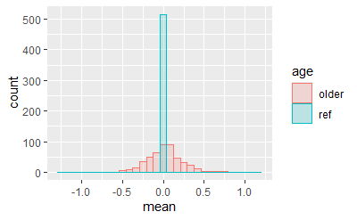

```r
plotdata = rbind(
                data.frame(vars=colnames(labpp),m=apply(labpp[ageLogi,],2,mean,na.rm=T),s=apply(labpp[ageLogi,],2,sd,na.rm=T),sk=apply(labpp[ageLogi,],2,skew,na.rm=T),age="ref"),
                data.frame(vars=colnames(labpp),m=apply(labpp[olderLogi,],2,mean,na.rm=T),s=apply(labpp[olderLogi,],2,sd,na.rm=T),sk=apply(labpp[olderLogi,],2,skew,na.rm=T),age="older")
                )
ggplot(plotdata,aes(x=m,colour=age,fill=age))+
  geom_histogram(position="identity",alpha=.2)+
  labs(x="mean")
```

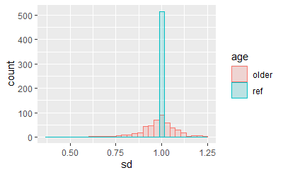

```r
ggplot(plotdata,aes(x=s,colour=age,fill=age))+
  geom_histogram(position="identity",alpha=.2)+
  labs(x="sd")
```

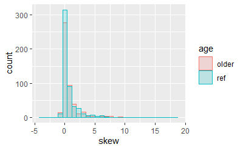

```r
ggplot(plotdata,aes(x=sk,colour=age,fill=age))+
  geom_histogram(position="identity",alpha=.2)+
  labs(x="skew")
```

generate all of the histograms

```r
skip=T
labVars = sort(labVars)

g = list()
failures = numeric()
for (i in 1:length(labVars))
{
  if(skip) break
    plotdata = data.frame(x=labpp[,labVars[i]],sex=factor(lab[,"sex"],c(0,1),c("male","female")),age=lab[,"age"])

    g[[i]] = ggplot(subset(plotdata,age>=20),aes(x=x,y=..density..,colour=sex,fill=sex))+
      geom_histogram(position="identity",alpha=.25)+
      labs(x=labVars[i],y="Count",title=labVars[i])+ #title=sprintf("%s - lambda = %.0f",levels(df0[,"group"])[i],lambda))+
      theme_minimal(base_size=8)+
      theme(axis.text.x=element_text(angle=90,vjust=.5))

}



library(cowplot)
nrow = 10
ncol = 10
maxPer = nrow*ncol-1

save=F
if(save)
{
  inds = 1:maxPer
  iter = 1
  while(min(inds) < length(g))
  {
    inds = inds[inds <= length(g)]
    l = g[inds]
    #print(length(l))
    #add legend
    leg = ggdraw(cowplot::get_legend(l[[1]]))
    for (i in 1:length(l)) l[[i]] = l[[i]] + theme(legend.position="none")
    l[[length(l)+1]] = leg

    fileName = sprintf("%s/results/nhanes_lab_hist_%02d.png",outputDir,iter)
    ggsave(fileName,marrangeGrob(l,nrow=nrow,ncol=ncol,top=NULL),width=16,height=16)
    inds = inds + maxPer
    iter=iter+1
  }

}
```

#clean up exam data -looks like grip and gait are the big ones -I want obesity as correlate

```r
#fix blood pressure and pool
di = sprintf("BPXDI%d",1:4)
for (j in 1:length(di))
{
  logi = exam[,di[j]] < 5
  logi[is.na(logi)] = F
  exam[logi,di[j]] = NA #there's a weird pileup at 0 that's probably wrong
  logi = exam[,di[j]] > 200
  logi[is.na(logi)] = F
  exam[logi,di[j]] = NA #doesn't happen, but just in case

}
exam[,"BPXDI"] = apply(exam[,di],1,median,na.rm=T) #mean or median; median good for one bad value

sys = sprintf("BPXSY%d",1:4)
for (j in 1:length(sys))
{
  logi = exam[,sys[j]] < 5
  logi[is.na(logi)] = F
  exam[logi,sys[j]] = NA #doesn't happen, but just in case
  logi = exam[,sys[j]] > 300
  logi[is.na(logi)] = F
  exam[logi,sys[j]] = NA #doesn't happen, but just in case

}
exam[,"BPXSY"] = apply(exam[,sys],1,median,na.rm=T) #mean or median; median good for one bad value

#binarize
exam[,"pulse"] = exam[,"BPXPULS"]-1 #abnormal pulse

#combine 20 foot walk
#they changed the name after 99
  #age-dependent distribution looks basically the same to me
comb = c("MSXW20TM","MSXWTIME")
logi = is.na(exam[,"MSXW20TM"])
logi[is.na(logi)] = F
exam[logi,"MSXW20TM"] = exam[logi,"MSXWTIME"]


#combine balance variables
#BAQ110 gates
#whether you pass or not is stored in the BAXPFC variable (4 tests, 2 attempts per)
#if you fail to pass, the time is recorded in the BAXFTC variable
cantStand = exam[,"BAQ110"] == 1 #give fails to people who can't stand (rare)
cantStand[is.na(cantStand)] = F
comb = sprintf("BAXPFC1%d",1:2)
exam[,"BAXPFC1"] = as.integer(apply(exam[,comb] == 2,1,mean,na.rm=T)) #take mean since it's binary
exam[logi,"BAXPFC1"] = 1
comb = sprintf("BAXPFC2%d",1:2)
exam[,"BAXPFC2"] = as.integer(apply(exam[,comb] == 2,1,mean,na.rm=T)) #take mean since it's binary
exam[logi,"BAXPFC2"] = 1
comb = sprintf("BAXPFC3%d",1:2)
exam[,"BAXPFC3"] = as.integer(apply(exam[,comb] == 2,1,mean,na.rm=T)) #take mean since it's binary
exam[logi,"BAXPFC3"] = 1
comb = sprintf("BAXPFC4%d",1:2)
exam[,"BAXPFC4"] = as.integer(apply(exam[,comb] == 2,1,mean,na.rm=T)) #take mean since it's binary
exam[logi,"BAXPFC4"] = 1

#fitness measures
  #only young people measured
#seems complicated, skipping for now

#obesity cuts:
exam[,"underweight"] = NA
logi = exam[,"BMXBMI"] <= 18.5
logi[is.na(logi)] = F
exam[logi,"underweight"] = 1
logi = exam[,"BMXBMI"] > 18.5
logi[is.na(logi)] = F
exam[logi,"underweight"] = 0

exam[,"obese"] = NA
logi = exam[,"BMXBMI"] <= 30
logi[is.na(logi)] = F
exam[logi,"obese"] = 0
logi = exam[,"BMXBMI"] > 30
logi[is.na(logi)] = F
exam[logi,"obese"] = 1

exam[,"obese2"] = NA
logi = exam[,"BMXBMI"] <= 40
logi[is.na(logi)] = F
exam[logi,"obese2"] = 0
logi = exam[,"BMXBMI"] > 40
logi[is.na(logi)] = F
exam[logi,"obese2"] = 1
```

```r
#MGDCGSZ is "Combined grip strength (kg): the sum of the largest reading from each hand."
examVars = c(pulse="pulse",dibp="BPXDI",sybp="BPXSY",gait="MSXW20TM",grip="MGDCGSZ",
             bmi="BMXBMI",underweight="underweight",obese="obese",v_obese="obese2",
             balance1="BAXPFC1",balance2="BAXPFC2",balance3="BAXPFC3",balance4="BAXPFC4" #balance 4 is about 50% success, balance 1 is close to 100%
             )

#add new ones to exam codex
examcodex[(examVars),] = NA
for (j in 1:length(examVars))
{
  examcodex[(examVars)[j],] = NA
  examcodex[(examVars)[j],"Variable.Name"] = examVars[j]
  examcodex[(examVars)[j],"Variable.Description"] = names(examVars)[j]
}

examcodex[,"class"] = examcodex[,"Data.File.Description"]

examcodex["pulse","class"] = "heart"
examcodex["BPXDI","class"] = "heart"
examcodex["BPXSY","class"] = "heart"
examcodex["MSXW20TM","class"] = "physical"
examcodex["MGDCGSZ","class"] = "physical"
examcodex["BMXBMI","class"] = "weight"
examcodex["underweight","class"] = "weight"
examcodex["obese","class"] = "weight"
examcodex["obese2","class"] = "weight"
examcodex["BAXPFC1","class"]     = "physical"
examcodex["BAXPFC2","class"]     = "physical"
examcodex["BAXPFC3","class"]     = "physical"
examcodex["BAXPFC4","class"]     = "physical"

examcodex["pulse","type"] = "binary"
examcodex["BPXDI","type"] = "numeric"
examcodex["BPXSY","type"] = "numeric"
examcodex["MSXW20TM","type"] = "numeric"
examcodex["MGDCGSZ","type"] = "numeric"
examcodex["BMXBMI","type"] = "numeric"
examcodex["underweight","type"] = "binary"
examcodex["obese","type"] = "binary"
examcodex["obese2","type"] = "binary"
examcodex["BAXPFC1","type"]     = "binary"
examcodex["BAXPFC2","type"]     = "binary"
examcodex["BAXPFC3","type"]     = "binary"
examcodex["BAXPFC4","type"]     = "binary"
```

#demographics

```r
#clean up race
#1: mexican, 2: other hispanic, 3: non-hispanic white, 4: black
demo[,"hispanic"] = as.integer( demo[,"RIDRETH1"] == 1 | demo[,"RIDRETH1"] == 2 )
demo[,"white"]    = as.integer( demo[,"RIDRETH1"] == 3 )
demo[,"black"]    = as.integer( demo[,"RIDRETH1"] == 4 )

#clean up income - Ratio of family income to poverty
demo[,"INDFMPIR"] = demo[,"INDFMPIR"]/5

#clean up sex
demo[,"sex"] = demo[,"RIAGENDR"] - 1

#fix marriage
demo[,"partner"] = NA
logi = demo[,"DMDMARTZ"] == 1 #married/living with partner
logi[is.na(logi)] = F
demo[logi,"partner"] = 1
logi = demo[,"DMDMARTZ"] == 2 #separated
logi[is.na(logi)] = F
demo[logi,"partner"] = 0
logi = demo[,"DMDMARTZ"] == 3 #never married
logi[is.na(logi)] = F
demo[logi,"partner"] = 0
```

survival

```r
#mort = read.csv("C:/data/nhanes/mortality_data.csv") #this is only old survival
#mort = read.csv("C:/data/nhanes/nhanes0102.csv") #same as prev
#mort = read.csv("C:/Users/Glen/OneDrive - Dalhousie University/analysis/missing_data/nhanes03040506.csv")
mort = read.csv("C:/data/nhanes/nhanes_mortality_all_years.csv")
rownames(mort) = mort[,"SEQN"]
#table(demo[!is.na(datapp[,"status"]),"SDDSRVYR"])
  # 5    8    9  #mortality_data.csv = nhanes0102.csv
  #4541 4111  430
  #4    5    7    8   12 #nhanes03040506.csv
  #4746 3252 4000 3998  456
  # 1     2     3     4     5     7     8     9    10    12    66  #nhanes_mortality_all_years.csv
  #6742 11007 10105 10337 10132  7746 10155  9955  9231   479 11236

#mortality data
demo[,"stop"] = NA
demo[,"status"] = NA
pts = intersect(rownames(mort),rownames(demo))
demo[pts,"years_remaining"] = mort[pts,"years_remaining"]
demo[pts,"stop"] = demo[pts,"years_remaining"] + demo[pts,"RIDAGEYR"]
demo[pts,"status"] = mort[pts,"status"]

s = Surv(demo[,"RIDAGEYR"],demo[,"stop"],demo[,"status"])
```

```r
addSurvival=T
dcuts = c(5,10,20)
survVar = sprintf("die_within_%.0fyear",dcuts)
names(survVar)=survVar
if(addSurvival)#add survival
{


  for (j in 1:length(dcuts))
  {
      demo[,survVar[j]] = NA
      #definite deaths:
      logi = demo[,"years_remaining"] <= dcuts[j] & demo[,"status"] == 1
      logi[is.na(logi)] = F
      demo[,survVar[j]][logi] = 1
      #definite censors:
      logi = demo[,"years_remaining"] > dcuts[j]
      logi[is.na(logi)] = F
      demo[,survVar[j]][logi] = 0
      #rest are NAs (default)


  }


  for (j in 1:length(survVar))
  {
    democodex[survVar[j],] = NA
    democodex[survVar[j],"name"] = survVar[j]
    democodex[survVar[j],"parsed"] = survVar[j]
    democodex[survVar[j],"class"] = "death"
    democodex[survVar[j],"type"] = "binary"
    democodex[survVar[j],"group"] = "demo"
  }


}
```

```r
#income: INDFMINC,INDFMPIR
#race: RIDRETH1,  #original race variable
      #RIDRETH2,  #linked variable
      #RIDRETH3  #updated to include asian
demoVars = c(age="RIDAGEYR",sex="sex",survey="SDDSRVYR",partner="partner",
             income="INDFMPIR",
             years_remaining="years_remaining",death_age="stop",death_status="status",
             survVar,
             #race="RIDRETH1",
             hispanic="hispanic",white="white",black="black"
             )

#add new ones to exam codex
democodex[names(demoVars),] = NA
for (j in 1:length(demoVars))
{
  democodex[(demoVars)[j],] = NA
  democodex[(demoVars)[j],"Variable.Name"] = demoVars[j]
  democodex[(demoVars)[j],"Variable.Description"] = names(demoVars)[j]
}

democodex[,"class"] = democodex[,"Data.File.Description"]

democodex["RIDAGEYR","class"] = "age"
democodex["RIAGENDR","class"] = "sex"
democodex["SDDSRVYR","class"] = "survey"
democodex["DMDMARTZ","class"] = "relationship"
democodex["INDFMPIR","class"] = "income"
democodex["years_remaining","class"] = "death"
democodex["stop","class"] = "death"
democodex["status","class"] = "death"
#democodex["RIDRETH1","class"] = "race"
democodex["hispanic","class"] = "race"
democodex["white","class"]     = "race"
democodex["black","class"]     = "race"


democodex["RIDAGEYR","type"] = "numeric"
democodex["RIAGENDR","type"] = "binary"
democodex["SDDSRVYR","class"] = "numeric"
democodex["DMDMARTZ","type"] = "binary"
democodex["INDFMPIR","type"] = "numeric"
democodex["years_remaining","type"] = "numeric"
democodex["stop","type"] = "numeric"
democodex["status","type"] = "binary"
#democodex["RIDRETH1","type"] = "categorical"
democodex["hispanic","type"] = "binary"
democodex["white","type"]     = "binary"
democodex["black","type"]     = "binary"
```

binary data

```r
file = sprintf("%s/nhanes_clinic/nhanes_clinic_preproc.csv",dataDir)
clinic = read.csv(file,row.names=1)
clinicVars = setdiff(colnames(clinic),c("AGE","SEX","SURVEY","parsed")) #not sure how parsed got in there... yikes
```

auxiliary questionnaire data

```r
aux = read.csv(sprintf("%s/nhanes_clinic/nhanes_clinic_aux_preproc.csv",dataDir),row.names=1)
auxCode = read.csv(sprintf("%s/nhanes_clinic/nhanes_clinic_aux_preproc_code.csv",dataDir),row.names=1)
auxVars = auxCode[,"name"]
```

#now clean everything up and merge together store as binary and continuous save codex

```r
labVars = setdiff(labVars,"age") #just in case it snuck in...

X = demo[,demoVars]


pts = intersect(rownames(X),rownames(labpp))
X[pts,labVars] = labpp[pts,labVars]

pts = intersect(rownames(X),rownames(exam))
X[pts,examVars] = exam[pts,examVars]

pts = intersect(rownames(X),rownames(clinic))
X[pts,clinicVars] = clinic[pts,clinicVars]

pts = intersect(rownames(X),rownames(aux))
X[pts,auxVars] = aux[pts,auxVars]

#must be an adult
X = subset(X,RIDAGEYR>=20)

#must have at least one clinic variable
logi = apply(is.na(X[,clinicVars]),1,sum) > 0
X = X[logi,]

write.csv(X,sprintf("%s/data/nhanes_preproc.csv",outputDir))
```

```r
remove_parentheses <- function(x) {
  gsub("\\s*\\([^)]*\\)", "", x)  # Remove parentheses and any content inside
}
```

#save code file

```r
bcode = read.csv(sprintf("%s/nhanes_clinic/nhanes_clinic_preproc_code.csv",dataDir),row.names=1)
bcode[,"type"] = "binary"
bcode["BPQ080","parsed"] = "high cholesterol"
lcode = labcodex[labVars,]
lcode[,"class"] = lcode[,"Data.File.Description"]
lcode[,"parsed"] = lcode[,"Variable.Description"]
lcode[,"name"] = lcode[,"Variable.Name"]
lcode = subset(lcode,!is.na(name))
addMe = setdiff(labVars,rownames(lcode))
for (j in 1:length(addMe))
{
  lcode[addMe[j],] = NA
  lcode[addMe[j],"name"] = addMe[j]
  lcode[addMe[j],"parsed"] = addMe[j]
  lcode[addMe[j],"class"] = addMe[j]
}
lcode[,"type"] = "numeric"
#clean up parsed so it's easier to find duplicates
lcode[,"parsed"] = tolower(lcode[,"parsed"])
for (i in 1:nrow(lcode))
{
  lcode[i,"parsed"] = remove_parentheses(lcode[i,"parsed"])
}
#special cases
lcode["SSSALIGG","parsed"] = "salmonella igg"

dcode = democodex[demoVars,]
dcode[,"parsed"] = dcode[,"Variable.Description"]
dcode[,"name"] = dcode[,"Variable.Name"]
ecode = examcodex[examVars,]
ecode[,"parsed"] = ecode[,"Variable.Description"]
ecode[,"name"] = ecode[,"Variable.Name"]

auxCode[,"type"] = "aux"


codex = rbind(data.frame(dcode[,c("name","parsed","class","type")],group="demo"),
              data.frame(ecode[,c("name","parsed","class","type")],group="exam"),
              data.frame(bcode[,c("name","parsed","class","type")],group="clinic"),
              data.frame(auxCode[,c("name","parsed","class","type")],group="aux"),
              data.frame(lcode[,c("name","parsed","class","type")],group="lab")
              )

write.csv(codex,sprintf("%s/data/nhanes_preproc_codex.csv",outputDir))
```